# Plotting and statistics

Martin Hanewald

1 August 2018

# 1 Introduction

This document introduces basic steps in explanatory analysis using plotting techniques in the **ggplot2** package.

*(Tip insert a new code-chunk with CTRL+ALT+I)*

# 2 Loading libraries

```r
library(tidyverse)
library(scales)
```

# 3 Loading the data

We load the midwest dataset from the package ggplot2.

```r
data(midwest)
midwest <- midwest %>% mutate_at(vars(county, state, inmetro, category), as.factor)
head(midwest)
```

| PID | county | state | area | poptotal | popdensity | popwhite | popblack | popamerindian | popasian | popother | percwhite | percblack | percamerindan | percasian | percother | popadults | perchsd | percollege | percprof | poppovertyknown | percpovertyknown | percbelowpoverty | percchildbelowpovert | percadultpoverty | percelderlypoverty | inmetro | category |
| --- | --- | --- | --- | --- | --- | --- | --- | --- | --- | --- | --- | --- | --- | --- | --- | --- | --- | --- | --- | --- | --- | --- | --- | --- | --- | --- | --- |
| 561 | ADAMS | IL | 0.052 | 66090 | 1270.9615 | 63917 | 1702 | 98 | 249 | 124 | 96.71206 | 2.5752761 | 0.1482826 | 0.37675897 | 0.18762294 | 43298 | 75.10740 | 19.63139 | 4.355859 | 63628 | 96.27478 | 13.151443 | 18.01172 | 11.009776 | 12.443812 | 0 | AAR |
| 562 | ALEXANDER | IL | 0.014 | 10626 | 759.0000 | 7054 | 3496 | 19 | 48 | 9 | 66.38434 | 32.9004329 | 0.1788067 | 0.45172219 | 0.08469791 | 6724 | 59.72635 | 11.24331 | 2.870315 | 10529 | 99.08714 | 32.244278 | 45.82651 | 27.385647 | 25.228976 | 0 | LHR |
| 563 | BOND | IL | 0.022 | 14991 | 681.4091 | 14477 | 429 | 35 | 16 | 34 | 96.57128 | 2.8617170 | 0.2334734 | 0.10673071 | 0.22680275 | 9669 | 69.33499 | 17.03382 | 4.488572 | 14235 | 94.95697 | 12.068844 | 14.03606 | 10.852090 | 12.697410 | 0 | AAR |
| 564 | BOONE | IL | 0.017 | 30806 | 1812.1176 | 29344 | 127 | 46 | 150 | 1139 | 95.25417 | 0.4122574 | 0.1493216 | 0.48691813 | 3.69733169 | 19272 | 75.47219 | 17.27895 | 4.197800 | 30337 | 98.47757 | 7.209019 | 11.17954 | 5.536013 | 6.217047 | 1 | ALU |
| 565 | BROWN | IL | 0.018 | 5836 | 324.2222 | 5264 | 547 | 14 | 5 | 6 | 90.19877 | 9.3728581 | 0.2398903 | 0.08567512 | 0.10281014 | 3979 | 68.86152 | 14.47600 | 3.367680 | 4815 | 82.50514 | 13.520249 | 13.02289 | 11.143211 | 19.200000 | 0 | AAR |
| 566 | BUREAU | IL | 0.050 | 35688 | 713.7600 | 35157 | 50 | 65 | 195 | 221 | 98.51210 | 0.1401031 | 0.1821340 | 0.54640215 | 0.61925577 | 23444 | 76.62941 | 18.90462 | 3.275891 | 35107 | 98.37200 | 10.399635 | 14.15882 | 8.179287 | 11.008586 | 0 | AAR |

We have 437 datasets.

Basic structure of the variables:

```r
str(midwest)
```

```
## Classes 'tbl_df', 'tbl' and 'data.frame':    437 obs. of  28 variables:
##  $ PID                 : int  561 562 563 564 565 566 567 568 569 570 ...
##  $ county              : Factor w/ 320 levels "ADAMS","ALCONA",..: 1 3 25 26 28 30 33 35 36 37 ...
##  $ state               : Factor w/ 5 levels "IL","IN","MI",..: 1 1 1 1 1 1 1 1 1 1 ...
##  $ area                : num  0.052 0.014 0.022 0.017 0.018 0.05 0.017 0.027 0.024 0.058 ...
##  $ poptotal            : int  66090 10626 14991 30806 5836 35688 5322 16805 13437 173025 ...
##  $ popdensity          : num  1271 759 681 1812 324 ...
##  $ popwhite            : int  63917 7054 14477 29344 5264 35157 5298 16519 13384 146506 ...
##  $ popblack            : int  1702 3496 429 127 547 50 1 111 16 16559 ...
##  $ popamerindian       : int  98 19 35 46 14 65 8 30 8 331 ...
##  $ popasian            : int  249 48 16 150 5 195 15 61 23 8033 ...
##  $ popother            : int  124 9 34 1139 6 221 0 84 6 1596 ...
##  $ percwhite           : num  96.7 66.4 96.6 95.3 90.2 ...
##  $ percblack           : num  2.575 32.9 2.862 0.412 9.373 ...
##  $ percamerindan       : num  0.148 0.179 0.233 0.149 0.24 ...
##  $ percasian           : num  0.3768 0.4517 0.1067 0.4869 0.0857 ...
##  $ percother           : num  0.1876 0.0847 0.2268 3.6973 0.1028 ...
##  $ popadults           : int  43298 6724 9669 19272 3979 23444 3583 11323 8825 95971 ...
##  $ perchsd             : num  75.1 59.7 69.3 75.5 68.9 ...
##  $ percollege          : num  19.6 11.2 17 17.3 14.5 ...
##  $ percprof            : num  4.36 2.87 4.49 4.2 3.37 ...
##  $ poppovertyknown     : int  63628 10529 14235 30337 4815 35107 5241 16455 13081 154934 ...
##  $ percpovertyknown    : num  96.3 99.1 95 98.5 82.5 ...
##  $ percbelowpoverty    : num  13.15 32.24 12.07 7.21 13.52 ...
##  $ percchildbelowpovert: num  18 45.8 14 11.2 13 ...
##  $ percadultpoverty    : num  11.01 27.39 10.85 5.54 11.14 ...
##  $ percelderlypoverty  : num  12.44 25.23 12.7 6.22 19.2 ...
##  $ inmetro             : Factor w/ 2 levels "0","1": 1 1 1 2 1 1 1 1 1 2 ...
##  $ category            : Factor w/ 16 levels "AAR","AAU","AHR",..: 1 15 1 6 1 1 13 1 1 8 ...
```

# 4 Basic plotting

Investigating the relationship between area and population.

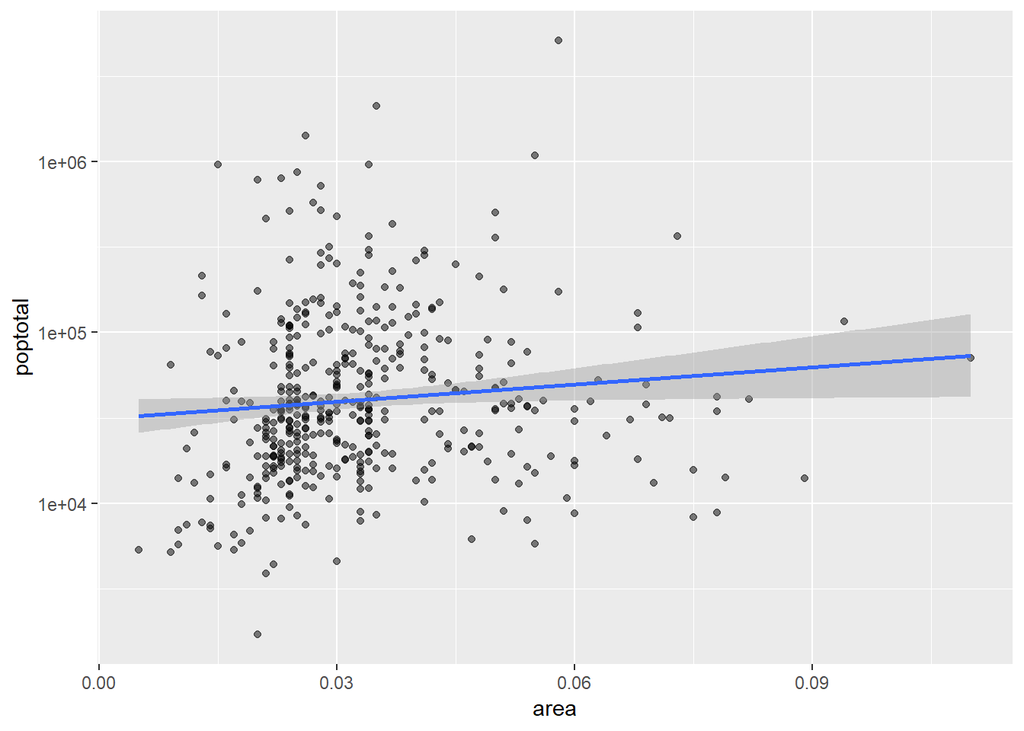

```r
midwest %>% ggplot(aes(x=area, y=poptotal)) + geom_point(alpha=.5) + geom_smooth(method="lm") + scale_y_log10()
```

The linear trend only shows a slight positive correlation between area and population.

# 5 Investigating the relationship between Education and Poverty

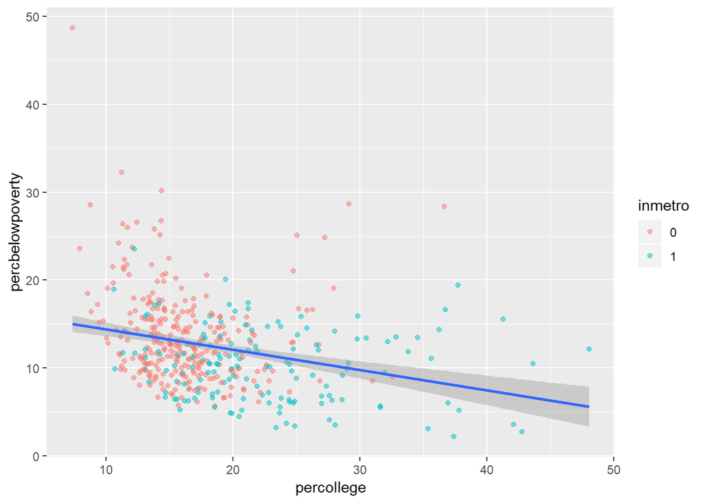

```r
midwest %>% ggplot(aes(x=percollege, y=percbelowpoverty)) + geom_point(aes(color=inmetro), alpha=.5) + geom_smooth(method="lm")
```

As expected there seems to be a negative correllation between college education and poverty.

# 6 Are people living in a metropolitan area more educated?

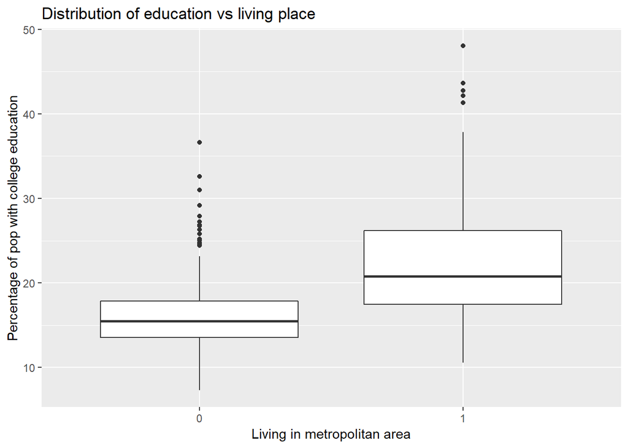

```r
midwest %>% ggplot(aes(y = percollege, x = inmetro)) + geom_boxplot() + labs(x = 'Living in metropolitan area', y = 'Percentage of pop with college education',
                                                                             title='Distribution of education vs living place')
```

What is the sample size?

```r
midwest %>% group_by(inmetro) %>% count()
```

| inmetro | n |
| --- | --- |
| 0 | 287 |
| 1 | 150 |

Perform a two-sample t-test:

```r
t.test(percollege ~ inmetro, data= midwest, alternative = 'less')
```

```
##
##  Welch Two Sample t-test
##
## data:  percollege by inmetro
## t = -9.7643, df = 198.24, p-value < 2.2e-16
## alternative hypothesis: true difference in means is less than 0
## 95 percent confidence interval:
##       -Inf -5.300755
## sample estimates:
## mean in group 0 mean in group 1
##        16.08258        22.46323
```

The p-value is very small, meaning the null-hypothesis, that people are equally educated in metropolitan or rural areas can be confidently rejected.

**Conclusion: There is very strong evidence, that people living in metropoliation areas are more educated.**

# 7 Investigating the relationship between race and poverty

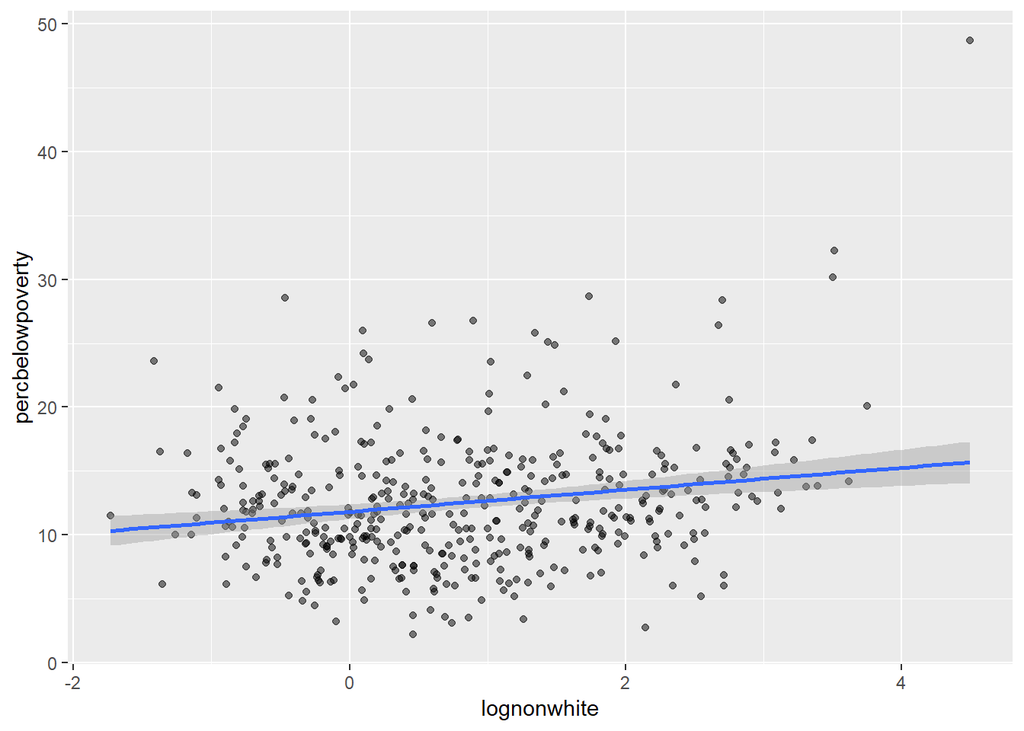

```r
midwest <- midwest %>%
    mutate(lognonwhite = log(100-percwhite))

midwest %>%
    ggplot(aes(x=lognonwhite, y=percbelowpoverty)) +
    geom_point(alpha=.5) +
    geom_smooth(method="lm")
```

## 7.1 Zooming out to “state level”

Calculating the mean “lognonwhite percentage” per state:

```r
plotdat <- midwest %>%
    group_by(state) %>%
    summarise(lognonwhite = mean(lognonwhite),
              percbelowpoverty = mean(percbelowpoverty))
plotdat
```

| state | lognonwhite | percbelowpoverty |
| --- | --- | --- |
| IL | 0.7876439 | 13.07645 |
| IN | 0.3869085 | 10.31844 |
| MI | 1.2045043 | 14.22479 |
| OH | 1.0352242 | 13.03307 |
| WI | 0.6113984 | 11.89484 |

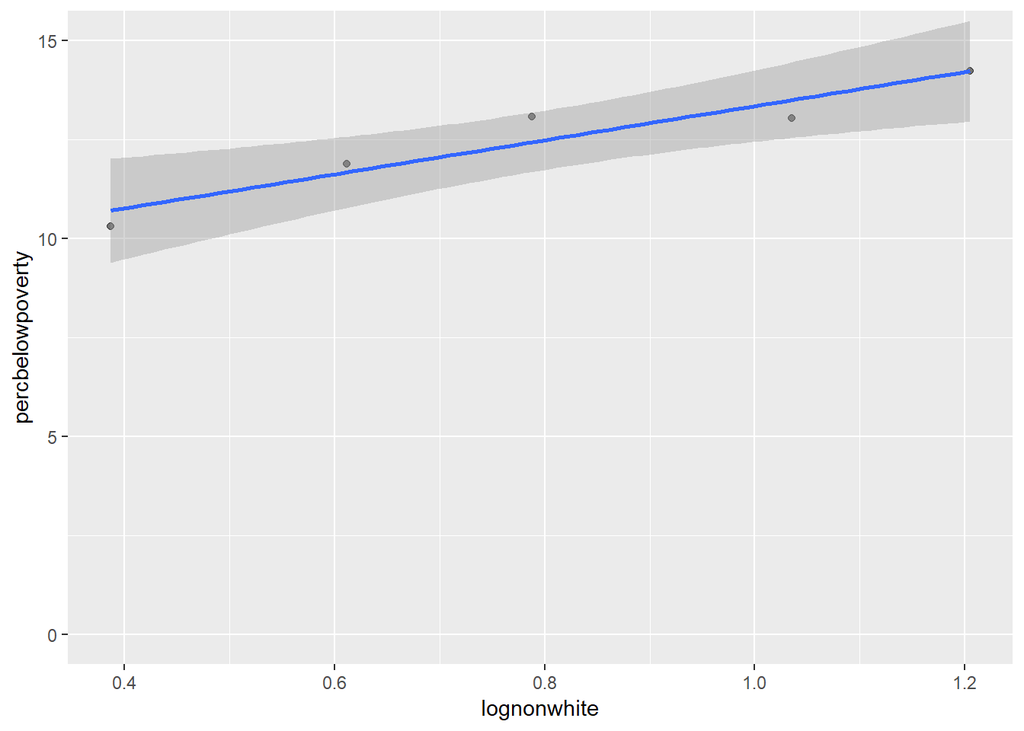

```r
plotdat %>% ggplot(aes(x=lognonwhite, y=percbelowpoverty)) +
    geom_point(alpha=.5) +
    geom_smooth(method="lm") +
    coord_cartesian(ylim=c(0,15))
```

## 7.2 Two-sample t-test

Let’s fortify that thesis with a t-test on two groups.

```r
testdat <- midwest %>%
    mutate(lognonwhite_cat = cut(lognonwhite,2))

testdat$lognonwhite_cat %>% table
```

```
## .
## (-1.74,1.38]   (1.38,4.5]
##          307          130
```

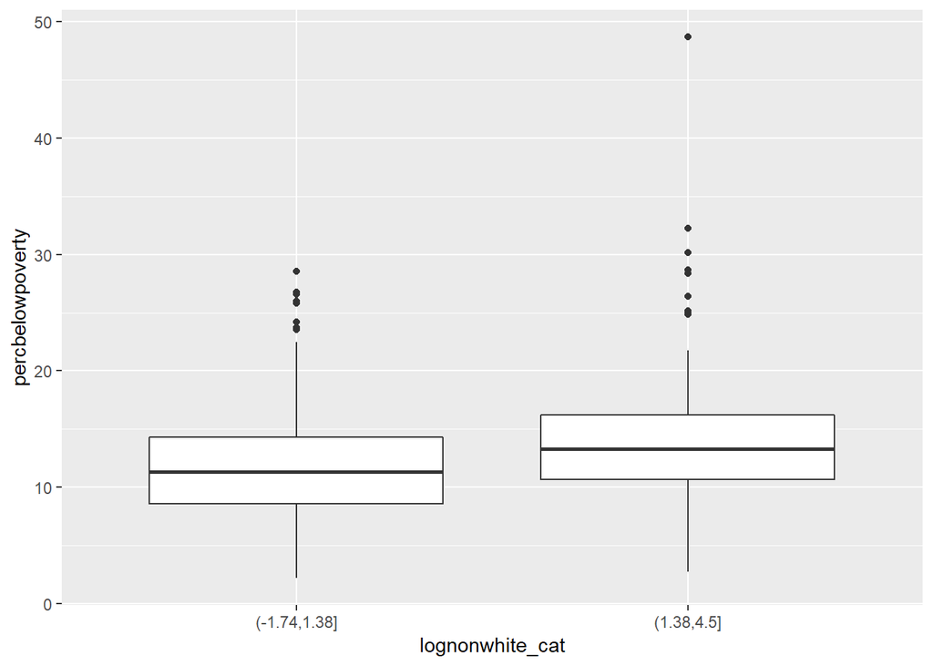

```r
testdat %>% ggplot(aes(y=percbelowpoverty, x=lognonwhite_cat)) + geom_boxplot()
```

The boxplot already gives evidence, that higher non-white population correlates with more poverty.

```r
t.test(percbelowpoverty ~ lognonwhite_cat, data=testdat)
```

```
##
##  Welch Two Sample t-test
##
## data:  percbelowpoverty by lognonwhite_cat
## t = -3.8793, df = 200.63, p-value = 0.000142
## alternative hypothesis: true difference in means is not equal to 0
## 95 percent confidence interval:
##  -3.395807 -1.107013
## sample estimates:
## mean in group (-1.74,1.38]   mean in group (1.38,4.5]
##                   11.84075                   14.09216
```

And the t-test confirms this thesis.